# Дипломный проект

#### Вывод: нулевая гипотеза отвергнута, различия есть, доверительные интервалы не пересекаются совсем, p_value = 0.0.

##### 7.1.2 Бутстреп в 3000 выборок по 846 показателям в выборке по столбцам оценок 10 и 6

```python
ar10 =  np.array(d[10]) # создать массив из колонки с оценкой 10
ar6 = np.array(d[6])# создать массив из колонки с оценкой 6
ar6 = ar6[~np.isnan(ar6)] # убрать наны из массива

# анализ проводится по средним значениям в столбцах, где наименования столбцов - выставленные оценки
# отправная точка бутстрепа - средние значения по столбцу 6 и по столбцу 10 датафрейма d
# логика характеристики 'Video_put_Kb' предполагают что значения в столбце 10 должны быть больше, чем в столбце 6, поэтому:
  # a) нулевая гипотеза требует наличие  p_value >= 0.05 и пересечение доверительных интервалов бутстрепных средних по столбцам
  # b) альтернативная - p_value < 0.05 и непересекающихся доверительных интервалов по средним бутстрепным выборкам

m_old6 = ar6.mean() # среднее значение исходного столбца с наименованием 6 датафрейма d, old - как будто начального МЕНЬШЕГО
m_new10 = ar10.mean() # среднее значение исходного столбца с наименованием 10 датафрейма d, new - как будто вторичного БОЛЬШЕГО
delta106 = m_new10 - m_old6 # разность средних значенийисходных столбцов датафрейма d, должна быть положительной по условиям

# Цикл бутстрепа
li6=[] # список сбора средних рандомных характеристики 'Video_put_Kb' по оценке 6
li10=[] # список сбора средних рандомных характеристики 'Video_put_Kb' по оценке 10
differences106 = [] # список сбора разностей средних рандомных выборок по 10 И 6
rasmer = 3000 # количество рандомных выборок
for i in range(1, rasmer+1):
    s6 = random.choices(ar6, k = 846) # новая случайная выборка по исходной 6 РАЗМЕРНОСЬЮ k
    s10 = random.choices(ar10, k = 846)# новая случайная выборка по исходной 10 РАЗМЕРНОСЬЮ k
    m6 = np.mean(s6) # среднее значение
    m10 = np.mean(s10) #  среднее значение
    diff106 = m10 - m6 # разность средних по каждой паре рандомных

    li6.append(m6) # список средних по рандомным выборкам
    li10.append(m10) # список средних по рандомным выборкам
    differences106.append(diff106) # список с разностями средних по каждой паре рандомных выборок

print(delta106, "- первичная разность средних по столбцам оценок, ориентир для p_value на графике")
print(' ')

ar_differences106 = np.array(differences106) # преобразовать список разностей средних в массив
average_ar_differences106 = ar_differences106.mean()
print(average_ar_differences106, "-средняя разность значений в списке разностей значений, справочно")
print(' ')

ar_differences106_center = ar_differences106 - average_ar_differences106
p_value = sum(ar_differences106_center >= delta106)/rasmer
print("p_value =",p_value,".(Если p_value меньше 0,05 - нулевая отвергается, если больше 0,05 - нулевая подтверждается)")
print(' ')


dovint6 = np.percentile(li6,[2.5,97.5])
dovint10 = np.percentile(li10,[2.5,97.5])
print(dovint6, "доверительный интервал рандомных средних показателей в столбце оценок 6")
print(dovint10, "доверительный интервал рандомных средних показателей в столбце оценок 10")
#
```

```
151.23608922594394 - первичная разность средних по столбцам оценок, ориентир для p_value на графике

149.4817513947991 -средняя разность значений в списке разностей значений, справочно

p_value = 0.25333333333333335 .(Если p_value меньше 0,05 - нулевая отвергается, если больше 0,05 - нулевая подтверждается)

[5772.16814539 6378.07908599] доверительный интервал рандомных средних показателей в столбце оценок 6
[5884.24514362 6566.54067376] доверительный интервал рандомных средних показателей в столбце оценок 10
```

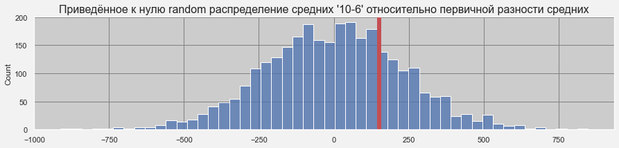

```python
# положение распределения относительно первичной разности средних по столбцам оценок

plt.figure(figsize=(15,3))
sns.histplot(ar_differences106_center, bins = 50)
plt.title("Приведённое к нулю random распределение средних '10-6' относительно первичной разности средних",fontsize=16)
plt.axvline(delta106, linewidth = 6,c='r' )
```

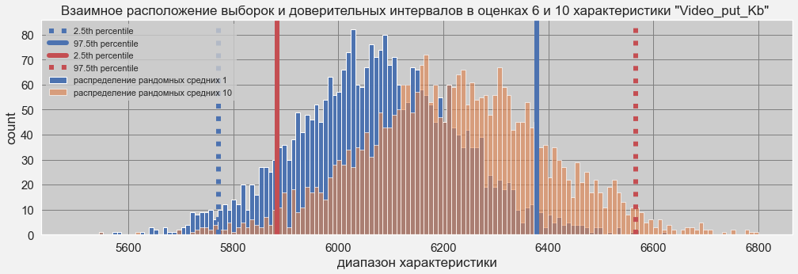

```python
plt.figure(figsize=(17,5))
bins = np.linspace(5500, 6800, 150)

plt.hist(li6, bins, alpha = 0.99, label='распределение рандомных средних 1')
plt.axvline(x=np.percentile(li6,[2.5]), ymin=0, ymax=1,label='2.5th percentile',c='b', linewidth = 6,linestyle = ':')
plt.axvline(x=np.percentile(li6,[97.5]), ymin=0, ymax=1,label='97.5th percentile',c='b', linewidth = 6,linestyle = '-')


plt.hist(li10, bins, alpha = 0.65, label='распределение рандомных средних 10')
plt.axvline(x=np.percentile(li10,[2.5]), ymin=0, ymax=1,label='2.5th percentile',c='r', linewidth = 6,linestyle = '-')
plt.axvline(x=np.percentile(li10,[97.5]), ymin=0, ymax=1,label='97.5th percentile',c='r', linewidth = 6,linestyle = ':')


plt.legend(loc='upper left')
plt.ylabel('count',fontsize=17)
plt.xlabel('диапазон характеристики',fontsize=17)
plt.tick_params(labelsize=15) # ШРИФТ

plt.title('Взаимное расположение выборок и доверительных интервалов в оценках 6 и 10 характеристики "Video_put_Kb" ',fontsize=17)



plt.show()
```

#### 7.2 Распределение random средних и доверительных интервалов этих средних по всем характеристикам и парам оценённых показателей по отношению к 10

```python
# создать список характеристик, где чем больше показатель - тем лучше
namesLa1 = names[0:2] # список строк
namesLa2 = names[3] # строка
namesLa3 = names[5] # строка
# преобразовать строки namesLa2 и namesLa2 в списки, состоящих из одного элемента для последующего сложения списков
namesLa22 = namesLa2.split(",")
namesLa33 = namesLa3.split(",")
# сложить списки в один
namesLa = namesLa1 + namesLa22 + namesLa33
namesLa
```

```
['Rapid_to_Kb', 'Rapid_out_Kb', 'Video_put_Kb', 'Web_to_rapid_Kb']
```

```python
# создать список характеристик, где чем меньше показатель - тем лучше
namesSm1 = names[2] # строка
namesSm2 = names[4] # строка
namesSm3 = names[6] # строка
# преобразовать строки в списки
namesSm11 = namesSm1.split(",")
namesSm22 = namesSm2.split(",")
namesSm33 = namesSm3.split(",")
# сложить списки
namesSm = namesSm11 + namesSm22 + namesSm33 # список, где чем меньше - тем лучше
namesSm
```

```
['retrans_(%)', 'video_delay_ms', 'web_flip_ms']
```

##### 7.2.1 Характеристик "чем больше - тем лучше"

```python
sldicLa = []
for i in namesLa:
    m = dfq1.groupby(['Q1', 'user_id'])[i].first().reset_index()
    qu = m[m['Q1']==1]
    for j in range(2,11):
        kku = m[m['Q1']==j].reset_index() # текущий в цикле фрейм
        kku = kku.drop(['Q1'], axis = 1) # столбец не нужен
        kku = kku.drop(['user_id'], axis = 1) # столбец не нужен
        kku = kku.rename(columns={i: j}) # проименовать столбцы по оценкам Q1
        qu = qu.merge(kku, how='outer', left_index=True, right_index=True ) # слияние
    qu = qu.rename(columns={i: 1}) # переименовать исходный
    bbb = qu[[1,2,3,4,5,6,7,8,9,10]]
    mmm = []
    for k in range(1,11):
        xx = np.array(bbb[k])
        xx = xx[~np.isnan(xx)]
        rasm = 3000
        www = []
        for e in range(1, rasm+1):
            ss1 = random.choices(xx, k = 846)
            pp1 = np.mean(ss1)
            www.append(pp1)

        mmm.append(www)

    sldicLa.append(mmm)
sldicLa[0][0][:2]
```

```
[1890.7099527186756, 1878.358936170213]
```

```python
ddd=pd.DataFrame(sldicLa)
ddf = ddd.copy().T
```

```python
ddf
```

|  | 0 | 1 | 2 | 3 |
| --- | --- | --- | --- | --- |
| 0 | [1890.7099527186756, 1878.358936170213, 1923.5... | [158.38709219858157, 151.23494089834517, 140.8... | [4637.6629669030735, 4962.286666666666, 4977.1... | [1781.395342789598, 1795.979657210402, 1869.67... |
| 1 | [1791.4055791962176, 1750.9555200945629, 1694.... | [142.33070921985816, 140.9597281323877, 139.76... | [5610.483392434989, 6329.256052009456, 5740.02... | [2156.1286643026006, 2291.4334397163125, 2127.... |
| 2 | [1804.2964420803783, 1831.1120685579197, 1755.... | [163.70405437352247, 168.89107565011818, 162.3... | [4750.400106382978, 4603.256288416076, 4670.21... | [1897.446867612293, 1819.7363593380614, 1846.9... |
| 3 | [2204.1111111111113, 2035.0731678486995, 2052.... | [186.68062647754138, 187.38614657210402, 183.5... | [5059.45353427896, 5104.750070921986, 5221.602... | [1920.0090070921985, 2056.3724704491724, 2021.... |
| 4 | [2007.4228959810875, 2213.1379905437348, 2106.... | [156.23393617021276, 153.5267257683215, 164.31... | [6095.501264775414, 6040.682281323876, 5630.77... | [1921.3538416075648, 1982.8071394799056, 1949.... |
| 5 | [2619.142151300236, 2739.357529550827, 2683.90... | [185.96938534278965, 184.76737588652483, 179.6... | [6279.824621749408, 6334.423262411347, 6133.34... | [2284.4672458628843, 2304.368132387707, 2478.4... |
| 6 | [2141.5551418439713, 2197.2533096926713, 2119.... | [182.17286052009456, 164.1222340425532, 173.31... | [5918.988014184398, 5915.420520094563, 6098.42... | [2095.5816666666665, 2138.5093262411347, 2088.... |
| 7 | [2175.2868439716312, 2204.7567139479906, 2160.... | [189.65167848699764, 191.86825059101653, 205.7... | [6260.6369739952725, 6006.998333333333, 6259.2... | [2150.506808510638, 2151.4936170212763, 2237.3... |
| 8 | [2676.597789598108, 2591.3523167848703, 2489.3... | [195.82274231678488, 189.67867612293145, 194.2... | [6524.677044917257, 6749.0723995271865, 6436.1... | [2349.5314420803784, 2457.0059574468087, 2486.... |
| 9 | [2680.22865248227, 2542.977978723404, 2473.449... | [187.27109929078014, 181.5060283687943, 186.52... | [6099.301252955082, 6072.042092198581, 6392.20... | [2210.7541134751773, 2274.6351300236406, 2306.... |

```python
ind = list(ddf.index)# для цикла
ind
```

```
[0, 1, 2, 3, 4, 5, 6, 7, 8, 9]
```

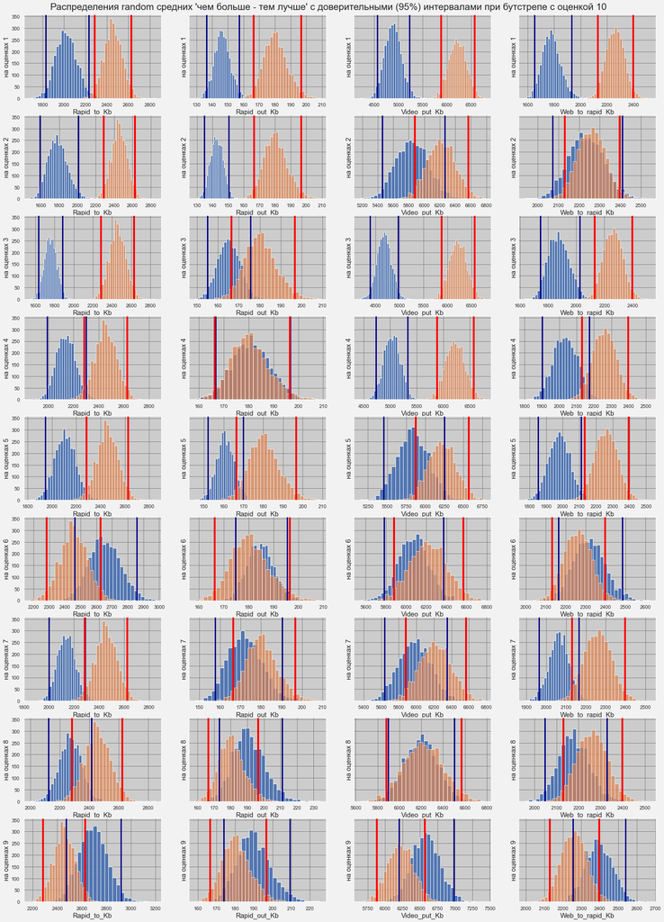

```python
fig, axs = plt.subplots(figsize=(25, 36), nrows=9, ncols=4, sharey=True)
ind = list(ddf.index)
for i in range(len(namesLa)):
    for j in range(len(ind)-1):
        data = ddf.iloc[j,i]
        ax = axs[j][i]
        ax.hist(data, bins=30,alpha=0.95)
        ax.axvline(x=np.percentile(ddf.iloc[j,i],[2.5]), color='DarkBlue', linewidth=3, linestyle='-')
        ax.axvline(x=np.percentile(ddf.iloc[j,i],[97.5]), color='DarkBlue', linewidth=3, linestyle='-')

        data1 = ddf.iloc[9,i]
        ax = axs[j][i]
        ax.hist(data1, bins=30, alpha=0.7)
        ax.axvline(x=np.percentile(ddf.iloc[9,i],[2.5]), color='red', linewidth=4, linestyle='-')
        ax.axvline(x=np.percentile(ddf.iloc[9,i],[97.5]), color='red', linewidth=4, linestyle='-')

        ax.set_ylabel('на оценках ' + str(j+1),fontsize=15)
        ax.set_xlabel(namesLa[i],fontsize=15 )
fig.suptitle("Распределения random средних 'чем больше - тем лучше' c доверительными (95%) интервалами при бутстрепе с оценкой 10 ", y = 0.89,fontsize=21)

plt.show()
```

##### 7.2.2 Характеристик "чем меньше - тем лучше"

```python
sldicSm = []
for i in namesSm:
    m = dfq1.groupby(['Q1', 'user_id'])[i].first().reset_index()
    qu = m[m['Q1']==1]
    for j in range(2,11):
        kku = m[m['Q1']==j].reset_index() # текущий в цикле фрейм
        kku = kku.drop(['Q1'], axis = 1) # столбец уже не нуженУ
        kku = kku.drop(['user_id'], axis = 1) # столбец уже не нуженУ
        kku = kku.rename(columns={i: j}) # проименовать столбцы по оценкам Q1
        qu = qu.merge(kku, how='outer', left_index=True, right_index=True ) # слияние
    qu = qu.rename(columns={i: 1}) # переименовать в 1
    bbb = qu[[1,2,3,4,5,6,7,8,9,10]]
    mmm = []
    for k in range(1,11):
        xx = np.array(bbb[k])
        xx = xx[~np.isnan(xx)]
        rasm = 3000
        www = []
        for e in range(1, rasm+1):
            ss1 = random.choices(xx, k = 846)
            pp1 = np.mean(ss1)
            www.append(pp1)

        mmm.append(www)

    sldicSm.append(mmm)
sldicSm[0][0][:3]
```

```
[1.996725768321513, 2.0612529550827423, 2.1130378250591013]
```

```python
ggg=pd.DataFrame(sldicSm)
ggf = ggg.copy().T
ggf.head()
```

|  | 0 | 1 | 2 |
| --- | --- | --- | --- |
| 0 | [1.996725768321513, 2.0612529550827423, 2.1130... | [2225.5709219858154, 2437.8380614657212, 2324.... | [258.3983451536643, 247.73640661938535, 254.75... |
| 1 | [2.083853427895981, 2.0709929078014184, 2.1080... | [2212.276595744681, 2199.3451536643024, 2361.3... | [193.45390070921985, 194.36406619385343, 200.5... |
| 2 | [1.9408747044917258, 1.9030260047281324, 1.849... | [2332.2836879432625, 2374.6040189125297, 2251.... | [226.3628841607565, 228.86761229314422, 212.73... |
| 3 | [2.0984397163120567, 2.2745744680851065, 1.984... | [2302.001182033097, 2164.113475177305, 2333.79... | [182.29550827423168, 178.15248226950354, 185.0... |
| 4 | [1.7621867612293143, 1.8437825059101656, 1.729... | [2180.478723404255, 2188.501182033097, 2246.89... | [194.73758865248226, 188.98936170212767, 187.1... |

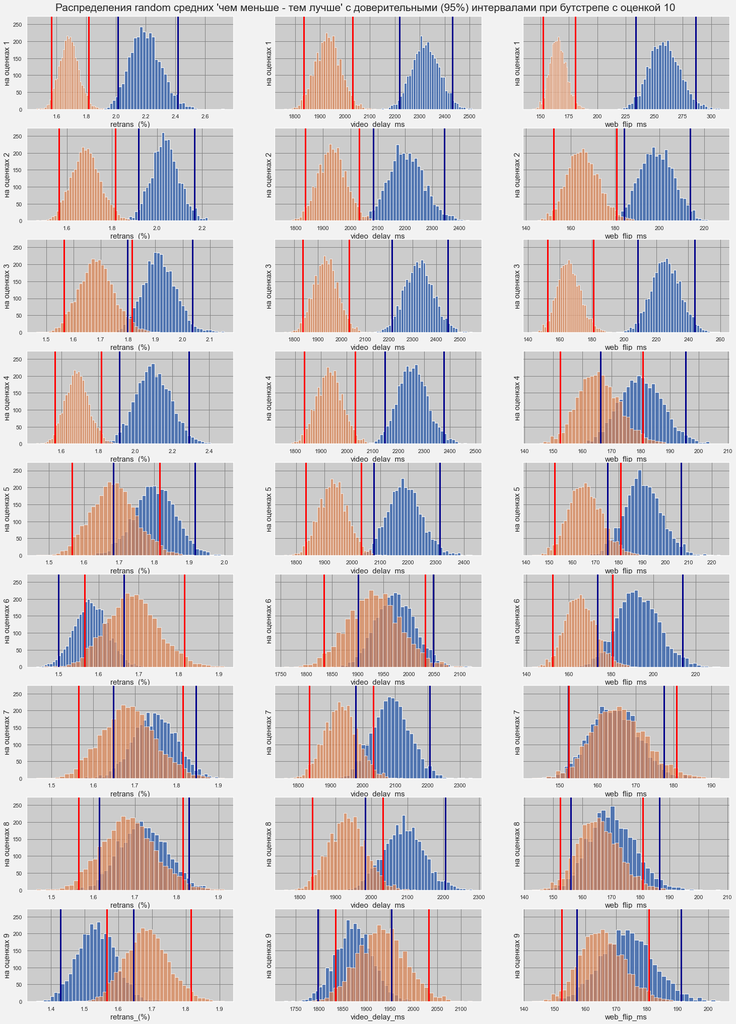

```python
fig, axs = plt.subplots(figsize=(25, 36), nrows=9, ncols=3, sharey=True)
ind = list(ggf.index)
for i in range(len(namesSm)):
    for j in range(len(ind)-1):
        data = ggf.iloc[j,i]
        ax = axs[j][i]
        ax.hist(data, bins=40,alpha=0.95)
        ax.axvline(x=np.percentile(ggf.iloc[j,i],[2.5]), color='DarkBlue', linewidth=3, linestyle='-')
        ax.axvline(x=np.percentile(ggf.iloc[j,i],[97.5]), color='DarkBlue', linewidth=3, linestyle='-')

        data1 = ggf.iloc[9,i]
        ax = axs[j][i]
        ax.hist(data1, bins=40, alpha=0.70)
        ax.axvline(x=np.percentile(ggf.iloc[9,i],[2.5]), color='red', linewidth=3, linestyle='-')
        ax.axvline(x=np.percentile(ggf.iloc[9,i],[97.5]), color='red', linewidth=3, linestyle='-')

        ax.set_ylabel('на оценках ' + str(j+1),fontsize=15)
        ax.set_xlabel(namesSm[i],fontsize=15 )
fig.suptitle("Распределения random средних 'чем меньше - тем лучше' c доверительными (95%) интервалами при бутстрепе с оценкой 10 ", y = 0.89,fontsize=21)

plt.show()
```

#### Представленные графики не информативны для оценки полной картины зависимости при пересечении доверительных интервалов. Кроме того, нужно учитывать p_value, который свидетельствует о правомерности отнесения данных к той или иной категории зависимости.

#### 7.3 Определение p_value сравниваемых пар и представление полной картины зависимости между числовыми показателями характеристик и оценками (используя структуру словаря)

##### 7.3.1 Словарь с полными параметрами необходимых данных по кластеру "чем больше - тем лучше"

```python
slovaric1 = {}
for i in namesLa:
    m = dfq1.groupby(['Q1', 'user_id'])[i].first().reset_index()
    qu = m[m['Q1']==1]
    for j in range(2,11):
        kku = m[m['Q1']==j].reset_index() #
        kku = kku.drop(['Q1'], axis = 1) #
        kku = kku.drop(['user_id'], axis = 1) #
        kku = kku.rename(columns={i: j}) #
        qu = qu.merge(kku, how='outer', left_index=True, right_index=True ) #
    qu = qu.rename(columns={i: 1}) #
    bbb = qu[[1,2,3,4,5,6,7,8,9,10]]
    mmm = {}
    for k in range(1,10):
        y = np.array(bbb[10])#
        x = np.array(bbb[k])#
        x = x[~np.isnan(x)]

        old = x.mean() # среднее значение исходного столбца с наименованием 1 датафрейма d, old - как будто начального МЕНЬШЕГО
        new = y.mean() # среднее значение исходного столбца с наименованием 10 датафрейма d, new - как будто вторичного БОЛЬШЕГО
        delta = new - old # разность средних значенийисходных столбцов датафрейма d, должна быть положительной по условиям


        rasm = 3000
        li[k] = []
        li10 = []
        li_diff = []
        for e in range(1, rasm+1):
            si = random.choices(x, k = 846)
            s10 = random.choices(y, k = 846)
            mi = np.mean(si)
            m10 = np.mean(s10)
            diff = m10 - mi

            li[k].append(mi) # список средних по рандомным выборкам
            li10.append(m10) # список средних по рандомным выборкам
            li_diff.append(diff) # список с разностями средних по каждой паре рандомных выборок
        ar_li_diff = np.array(li_diff)
        average_ar_li_diff = ar_li_diff.mean()
        ar_li_diff_center = ar_li_diff - average_ar_li_diff
        p_value = sum(ar_li_diff_center >= delta)/rasmer

        dovinti = np.percentile(li[k],[2.5,97.5])
        dovint10 = np.percentile(li10,[2.5,97.5])
        mmm[k] = [p_value,delta,dovinti,dovint10 ]

    slovaric1[i] = mmm
slovaric1['Rapid_to_Kb'][1] # срез использован для контроля правильности при малом формате представления
```

```
[0.0003333333333333333,
 429.530248760198,
 array([1836.89024823, 2244.06780142]),
 array([2294.79756235, 2627.31442405])]
```

```python
slo1 = slovaric1.copy()
```

##### 7.3.2 Словарь с полными параметрами необходимых данных по кластеру "чем меньше - тем лучше".

```python
slovaric2 = {}
for i in namesSm:
    m = dfq1.groupby(['Q1', 'user_id'])[i].first().reset_index()
    qu = m[m['Q1']==1]
    for j in range(2,11):
        kku = m[m['Q1']==j].reset_index() #
        kku = kku.drop(['Q1'], axis = 1) #
        kku = kku.drop(['user_id'], axis = 1) #
        kku = kku.rename(columns={i: j}) #
        qu = qu.merge(kku, how='outer', left_index=True, right_index=True ) #
    qu = qu.rename(columns={i: 1}) #
    bbb = qu[[1,2,3,4,5,6,7,8,9,10]]
    mmm = {}
    for k in range(1,10):
        y = np.array(bbb[10])# old
        x = np.array(bbb[k])# new
        x = x[~np.isnan(x)]

        old = y.mean() # среднее значение исходного столбца с наименованием 1 датафрейма d, old - как будто начального МЕНЬШЕГО
        new = x.mean() # среднее значение исходного столбца с наименованием 10 датафрейма d, new - как будто вторичного БОЛЬШЕГО
        delta = new - old # разность средних значенийисходных столбцов датафрейма d, должна быть положительной по условиям


        rasm = 3000
        li[k] = []
        li10 = []
        li_diff = []
        for e in range(1, rasm+1):
            si = random.choices(x, k = 846)
            s10 = random.choices(y, k = 846)
            mi = np.mean(si)
            m10 = np.mean(s10)
            diff = mi - m10

            li[k].append(mi) # список средних по рандомным выборкам
            li10.append(m10) # список средних по рандомным выборкам
            li_diff.append(diff) # список с разностями средних по каждой паре рандомных выборок
        ar_li_diff = np.array(li_diff)
        average_ar_li_diff = ar_li_diff.mean()
        ar_li_diff_center = ar_li_diff - average_ar_li_diff
        p_value = sum(ar_li_diff_center >= delta)/rasmer

        dovinti = np.percentile(li[k],[2.5,97.5])
        dovint10 = np.percentile(li10,[2.5,97.5])
        mmm[k] = [p_value,delta,dovinti,dovint10 ]

    slovaric2[i] = mmm
slovaric2['retrans_(%)'][1] # срез использован для контроля правильности при малом формате представления
```

```
[0.0,
 0.5140869016512912,
 array([2.01206708, 2.41765012]),
 array([1.56377896, 1.80935343])]
```

```python
slo2 = slovaric2.copy()
```

#### Разбивка на кластеры была нужна из-за разного "направления" в расчётах разностей средних в гипотезах

##### 7.3.3 Сложение словарей

```python
sloslo = dict(list(slo1.items())+list(slo2.items()))
sloslo['web_flip_ms'][9] # срез использован для контроля правильности при малом формате представления
```

```
[0.24233333333333335,
 8.08860281701331,
 array([157.2196513, 191.8197104]),
 array([152.43433806, 180.8322695 ])]
```

##### 7.3.4 Словарь в датафрейм

```python
sl = pd.DataFrame.from_dict(sloslo, orient='index')
sl
```

|  | 1 | 2 | 3 | 4 | 5 | 6 | 7 | 8 | 9 |
| --- | --- | --- | --- | --- | --- | --- | --- | --- | --- |
| Rapid_to_Kb | [0.0003333333333333333, 429.530248760198, [183... | [0.0, 674.5902988855112, [1582.3064358747044, ... | [0.0, 696.7520124386249, [1631.149706855792, 1... | [0.003, 315.75596090641784, [1983.545123522458... | [0.0013333333333333333, 347.07418166939397, [1... | [0.927, -198.10979776701151, [2460.33869739952... | [0.0023333333333333335, 318.1641893617016, [19... | [0.05533333333333333, 186.52767492871226, [212... | [0.9373333333333334, -228.757754335777, [2460.... |
| Rapid_out_Kb | [0.0, 33.81548121189496, [136.75274822695036, ... | [0.0, 37.80138973319825, [134.84283333333335, ... | [0.048666666666666664, 15.365293762502262, [15... | [0.532, -0.9322049241768866, [166.796211288416... | [0.017666666666666667, 19.525351882160408, [15... | [0.6776666666666666, -4.460833274816878, [174.... | [0.24066666666666667, 7.984370685579165, [157.... | [0.7956666666666666, -10.257414881431117, [172... | [0.791, -9.616943600135102, [173.2130602836879... |
| Video_put_Kb | [0.0, 1340.978606534064, [4553.578231973996, 5... | [0.078, 376.9345651806807, [5437.077433806147,... | [0.0, 1546.060208037824, [4388.06041459811, 49... | [0.0, 1193.158923484978, [4731.235434397164, 5... | [0.06566666666666666, 389.62852427714006, [544... | [0.247, 151.23608922594394, [5778.88301536643,... | [0.17333333333333334, 239.78565803782385, [562... | [0.453, 26.366579171844933, [5897.777542848699... | [0.9066666666666666, -353.51881717225933, [619... |
| Web_to_rapid_Kb | [0.0, 480.510573730425, [1655.5292201536643, 1... | [0.4166666666666667, 26.879940898344557, [2068... | [0.0, 383.415853718858, [1746.1855579196217, 2... | [0.008333333333333333, 222.86892463818208, [19... | [0.0006666666666666666, 280.83912893253296, [1... | [0.718, -54.43581817756285, [2162.594075945626... | [0.013, 196.01300756501178, [1967.199574763593... | [0.203, 81.33239794301835, [2052.016070626478,... | [0.9123333333333333, -133.97822436776096, [225... |
| retrans_(%) | [0.0, 0.5140869016512912, [2.0120670803782508,... | [0.0, 0.3519064505234719, [1.9175948581560283,... | [0.0036666666666666666, 0.22931743953446082, [... | [0.0003333333333333333, 0.41248717061638684, [... | [0.09133333333333334, 0.1162165848336063, [1.6... | [0.9136666666666666, -0.10414729770849429, [1.... | [0.228, 0.06186359338061442, [1.65222606382978... | [0.3403333333333333, 0.033801394067899615, [1.... | [0.951, -0.14805153266980575, [1.4305514184397... |
| video_delay_ms | [0.0, 391.6076894363571, [2213.866548463357, 2... | [0.0003333333333333333, 274.56978216818675, [2... | [0.0, 394.61254773595215, [2217.6383865248226,... | [0.0003333333333333333, 323.97439889292514, [2... | [0.0016666666666666668, 256.2176759410802, [20... | [0.257, 40.506074011656665, [1902.15481678487,... | [0.018333333333333333, 157.61716312056728, [19... | [0.014666666666666666, 157.23565109307606, [19... | [0.8386666666666667, -61.09443351808795, [1797... |
| web_flip_ms | [0.0, 93.29426402886648, [233.25901300236407, ... | [0.0003333333333333333, 33.04833671057074, [18... | [0.0, 60.28568103291508, [208.4216903073286, 2... | [0.08166666666666667, 14.505218243671777, [166... | [0.009333333333333334, 24.668757955991993, [17... | [0.017666666666666667, 27.14210144418695, [173... | [0.543, -1.155472813238788, [152.2467789598108... | [0.33666666666666667, 4.310180107723426, [155.... | [0.24233333333333335, 8.08860281701331, [157.2... |

```python
nu = np.zeros((7, 9)) # создать нулевой массив, размеры в виде кортежа
nu = nu.astype('int')
nu
```

```
array([[0, 0, 0, 0, 0, 0, 0, 0, 0],
       [0, 0, 0, 0, 0, 0, 0, 0, 0],
       [0, 0, 0, 0, 0, 0, 0, 0, 0],
       [0, 0, 0, 0, 0, 0, 0, 0, 0],
       [0, 0, 0, 0, 0, 0, 0, 0, 0],
       [0, 0, 0, 0, 0, 0, 0, 0, 0],
       [0, 0, 0, 0, 0, 0, 0, 0, 0]])
```

##### 7.3.5 График зависимости оценок от характеристик, построенныq на основе p_value

```python
nu1 = np.zeros((7, 9)) # нулевой массив
#nu1 = nu.astype('int')
for i in range(len(sl)):
    for j in range(len(list(sl.columns))):
        a = sl.iloc[i,j][0].round(3) # на 0-ом месте в датафрейме sl стоят значения p_value
        #if a >=0.05:
            #a = 1
        #else:
            #a = 0
        nu1[i,j] = a

nu1
```

```
array([[0.   , 0.   , 0.   , 0.003, 0.001, 0.927, 0.002, 0.055, 0.937],
       [0.   , 0.   , 0.049, 0.532, 0.018, 0.678, 0.241, 0.796, 0.791],
       [0.   , 0.078, 0.   , 0.   , 0.066, 0.247, 0.173, 0.453, 0.907],
       [0.   , 0.417, 0.   , 0.008, 0.001, 0.718, 0.013, 0.203, 0.912],
       [0.   , 0.   , 0.004, 0.   , 0.091, 0.914, 0.228, 0.34 , 0.951],
       [0.   , 0.   , 0.   , 0.   , 0.002, 0.257, 0.018, 0.015, 0.839],
       [0.   , 0.   , 0.   , 0.082, 0.009, 0.018, 0.543, 0.337, 0.242]])
```

```python
nu2 = np.zeros((7, 9)) # нулевой массив
nu2 = nu.astype('int')
for i in range(len(sl)):
    for j in range(len(list(sl.columns))):
        a = sl.iloc[i,j][0].round(3) # на 0-ом месте в датафрейме sl стоят значения p_value
        if a >=0.05:
            a = 1
        else:
            a = 0
        nu2[i,j] = a

nu2
```

```
array([[0, 0, 0, 0, 0, 1, 0, 1, 1],
       [0, 0, 0, 1, 0, 1, 1, 1, 1],
       [0, 1, 0, 0, 1, 1, 1, 1, 1],
       [0, 1, 0, 0, 0, 1, 0, 1, 1],
       [0, 0, 0, 0, 1, 1, 1, 1, 1],
       [0, 0, 0, 0, 0, 1, 0, 0, 1],
       [0, 0, 0, 1, 0, 0, 1, 1, 1]])
```

#### Здесь нули - это отвергнутые нулевые гипотезы при соответствующих сравнениях данных столбцов оценок с "10", от единицы до девяти слева направо.

```python
dfnu2 = pd.DataFrame(nu2)
dfnu2.columns = sl.columns
dfnu2.index = sl.index
df_p_value = dfnu2

df_p_value
```

|  | 1 | 2 | 3 | 4 | 5 | 6 | 7 | 8 | 9 |
| --- | --- | --- | --- | --- | --- | --- | --- | --- | --- |
| Rapid_to_Kb | 0 | 0 | 0 | 0 | 0 | 1 | 0 | 1 | 1 |
| Rapid_out_Kb | 0 | 0 | 0 | 1 | 0 | 1 | 1 | 1 | 1 |
| Video_put_Kb | 0 | 1 | 0 | 0 | 1 | 1 | 1 | 1 | 1 |
| Web_to_rapid_Kb | 0 | 1 | 0 | 0 | 0 | 1 | 0 | 1 | 1 |
| retrans_(%) | 0 | 0 | 0 | 0 | 1 | 1 | 1 | 1 | 1 |
| video_delay_ms | 0 | 0 | 0 | 0 | 0 | 1 | 0 | 0 | 1 |
| web_flip_ms | 0 | 0 | 0 | 1 | 0 | 0 | 1 | 1 | 1 |

##### Преобразовать массив нулей и единиц в датафрейм. Колонка "the_trend_however" - сумма единиц (то есть подтверждённых нулевых гипотез об отсутствии различий) в строке.

```python
dfnu2 = pd.DataFrame(nu2)
dfnu2.columns = sl.columns
dfnu2.index = sl.index
df_p_value2 = dfnu2.T
df_p_value2["the_trend_however"] = df_p_value2.sum(axis=1)
#df_p_value.loc['Total']= df_p_value.sum()

df_p_value2
```

|  | Rapid_to_Kb | Rapid_out_Kb | Video_put_Kb | Web_to_rapid_Kb | retrans_(%) | video_delay_ms | web_flip_ms | the_trend_however |
| --- | --- | --- | --- | --- | --- | --- | --- | --- |
| 1 | 0 | 0 | 0 | 0 | 0 | 0 | 0 | 0 |
| 2 | 0 | 0 | 1 | 1 | 0 | 0 | 0 | 2 |
| 3 | 0 | 0 | 0 | 0 | 0 | 0 | 0 | 0 |
| 4 | 0 | 1 | 0 | 0 | 0 | 0 | 1 | 2 |
| 5 | 0 | 0 | 1 | 0 | 1 | 0 | 0 | 2 |
| 6 | 1 | 1 | 1 | 1 | 1 | 1 | 0 | 6 |
| 7 | 0 | 1 | 1 | 0 | 1 | 0 | 1 | 4 |
| 8 | 1 | 1 | 1 | 1 | 1 | 0 | 1 | 6 |
| 9 | 1 | 1 | 1 | 1 | 1 | 1 | 1 | 7 |

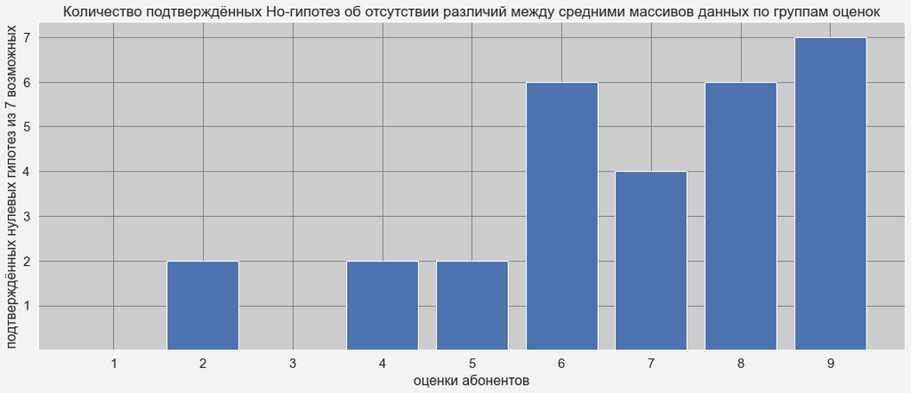

```python
c = list(range(1,10))
ww = list(range(1,8))
fig, ax = plt.subplots(figsize=(18,7))
plt.bar(df_p_value2.index, df_p_value2['the_trend_however'],width=0.8)
plt.title("Количество подтверждённых Ho-гипотез об отсутствии различий между средними массивов данных по группам оценок",fontsize=17)
plt.ylabel('подтверждённых нулевых гипотез из 7 возможных',fontsize=16)
plt.xlabel('оценки абонентов',fontsize=16)
plt.yticks(ww)
plt.xticks(c)
plt.tick_params(labelsize=15) # ШРИФТ
```

### Вывод. Прослеживается зависимость: средние значения характеристик у абонентов, которые выставили низкие оценки, явно отличаются и хуже характеристик у абонентов, которые выставили высокие оценки.

#### 7.3.6 p_value подтверждённых нулевых гипотез, распределённые по техническим характеристикам.

```python
dfnu3 = pd.DataFrame(nu2)
dfnu3.columns = sl.columns
dfnu3.index = sl.index
df_p_value3 = dfnu3
df_p_value3["confirmed_null_hypotheses_in_technical"] = df_p_value3.sum(axis=1)
df_p_value3s = df_p_value3.sort_values(by="confirmed_null_hypotheses_in_technical")
df_p_value3s
```

|  | 1 | 2 | 3 | 4 | 5 | 6 | 7 | 8 | 9 | confirmed_null_hypotheses_in_technical |
| --- | --- | --- | --- | --- | --- | --- | --- | --- | --- | --- |
| video_delay_ms | 0 | 0 | 0 | 0 | 0 | 1 | 0 | 0 | 1 | 2 |
| Rapid_to_Kb | 0 | 0 | 0 | 0 | 0 | 1 | 0 | 1 | 1 | 3 |
| Web_to_rapid_Kb | 0 | 1 | 0 | 0 | 0 | 1 | 0 | 1 | 1 | 4 |
| web_flip_ms | 0 | 0 | 0 | 1 | 0 | 0 | 1 | 1 | 1 | 4 |
| Rapid_out_Kb | 0 | 0 | 0 | 1 | 0 | 1 | 1 | 1 | 1 | 5 |
| retrans_(%) | 0 | 0 | 0 | 0 | 1 | 1 | 1 | 1 | 1 | 5 |
| Video_put_Kb | 0 | 1 | 0 | 0 | 1 | 1 | 1 | 1 | 1 | 6 |

#### Чем меньше сумма в столбце confirmed_null_hypotheses_in_technical, тем больше у этой характеристики отвергнутых нулевых гипотез, то есть тем больше у этих характеристик различий между доверительными интервалами в текущей оценке и эталонной "10" и, следовательно, необходимостью их модернизации.

#### Исходя из приведённого анализа в первую очередь необходимо улучшить показатели Rapid_to_Kb, video_delay_ms, Web_to_rapid_Kb и web_flip_ms.

### 8. Статистический анализ. Статистические тесты

#### Абоненты, поставившие оценки 9 и 10, не интересны с точки зрения удержания таковыми, - они и так лояльны при любых условиях, и их всё устраивает. Поставленную же задачу выявить характеристики, в первуюю очередь нуждающиеся в улучшении, можно только при анализе мнения абонентов, высказывающих претензии.

Основа идеи статистического анализа: 1) оценкой у абонента служили числа от 1 до 10, то есть служили 10 чисел, но с другой стороны 10 как бы диапазонов 2) оценку абоненты выставляли не каждой технической характеристике, а оператору в целом по случайно сложившимся в общий комплекс техническим характеристикам. Отсюда следуют два аспекта: 2.1) если абоненту важны все технические характеристики одинаково и, вследствии этого он подходит к оценке связи комплексно, то необходимо разнообразные единицы измерения всех технических характеристик привести к одной базе с целью их дальнейшего суммирования и измерения суммы. Негоже складывать в одном смысловом комплексе байты и секунды. 2.2) если абонент подходит к оценке оператора по одному, но важному для него критерию, этот критерий нужно вычленять в какой бы характеристике он ни находился и тоже этот единичный критерий корректно измерять. 3) технологически возможные характеристики каждого типа - в диапазоне от min до max - могут быть разбиты на диапазоны. 4) каждому диапазону технических характеристик поэтому также может быть присвоена уже обЪективная оценка (пусть и эрзац). 5) каждая техническая характеристика абонента будет принадлежать диапазону с оценкой от 1(ужасно) до 10(великолепно). 6) будет возможно сравнить субъективную оценку абонента Q1 объктивной оценкой (по этой же шкале) доставшейся услуги. 7) так как основой будущего анализа служит датафрейм base, в котором отсутствуют оценки 10 и 9, в дальнейшем предпочтительнее использовать, исходя из изложенной логики, деление диапазонов технических характеристик на 8 частей.

#### 8.1 Формирование датафрейма df8, состоящего из дискретных оценок технических характеристик

```python
df8 = base.copy()
```

```python
# лист названий столбцов тезнических характеристик
li = list(df8.columns)[2:-2]
print(li)
```

```
['Traffic', 'Rapid_to_Kb', 'Rapid_out_Kb', 'retrans_(%)', 'Video_put_Kb', 'video_delay_ms', 'Web_to_rapid_KB', 'web_flip_ms']
```

```python
# создание списка характеристик, где чем больше - тем лучше

li_b1 = li[0:3] # список строк
li_b2 = li[4] # строка
li_b3 = li[6] # строка

# преобразовать просто строки li_b2 И li_b3 в списки одного элемента для последующего сложения
li_b22 = li_b2.split(",")
li_b33 = li_b3.split(",")

# сложение списков
li_b = li_b1 + li_b22 + li_b33
li_b  # (_b - больше)
```

```
['Traffic', 'Rapid_to_Kb', 'Rapid_out_Kb', 'Video_put_Kb', 'Web_to_rapid_KB']
```

```python
# создание списка характеристик, где чем меньше - тем лучше

li_m1 = li[3] #
li_m2 = li[5] #
li_m3 = li[7] #

#
li_m11 = li_m1.split(",")
li_m22 = li_m2.split(",")
li_m33 = li_m3.split(",")

# СЛОЖИТЬ
li_m = li_m11 + li_m22 + li_m33 #
li_m # (_m - меньше)
```

```
['retrans_(%)', 'video_delay_ms', 'web_flip_ms']
```

```python
# расширение df8 новыми модернизированными столбцами чем больше характеристика - тем выше оценка
i=0
for i in range(len(li_b)):
    qq = li_b[i] + '_m'    # _m - модернизированное название столбца в цикле
    a = df8[li_b[i]].max() # присвоить a максимальное значение i-того технического пораметра в цикле
    c = df8[li_b[i]]       # текущий технический параметр
    df8[qq] = ((c / (a/8)).apply(np.ceil)).astype(int)   # новый столбец ,
                                                         # значение ячейки которого будет равно номеру диапазона/оценки,
                                                         # округлённого в большую сторону до целого.
    df8[qq] = np.where((df8[qq] == 0), 1, df8[qq]) # заменить нули естественного происхождения на единицы
    i = i+1
df8.head()
```

|  | user_id | Q1 | Traffic | Rapid_to_Kb | Rapid_out_Kb | retrans_(%) | Video_put_Kb | video_delay_ms | Web_to_rapid_KB | web_flip_ms | Q2 | rank | Traffic_m | Rapid_to_Kb_m | Rapid_out_Kb_m | Video_put_Kb_m | Web_to_rapid_KB_m |
| --- | --- | --- | --- | --- | --- | --- | --- | --- | --- | --- | --- | --- | --- | --- | --- | --- | --- |
| 2 | 4 | 8 | 179.18564 | 2590.97 | 325.88 | 0.80 | 7053.81 | 3218 | 1221.02 | 51 | 3 | 1 | 2 | 3 | 6 | 4 | 2 |
| 3 | 5 | 2 | 351.99208 | 731.61 | 223.54 | 1.15 | 4550.38 | 1767 | 2336.56 | 68 | 2 | 1 | 4 | 1 | 4 | 3 | 3 |
| 6 | 7 | 2 | 448.88413 | 438.27 | 81.32 | 1.98 | 1699.64 | 4223 | 856.05 | 220 | 4 | 1 | 5 | 1 | 2 | 1 | 2 |
| 8 | 9 | 1 | 783.64464 | 1786.99 | 271.77 | 0.84 | 6802.42 | 1200 | 1837.02 | 132 | 1 | 1 | 8 | 3 | 5 | 4 | 3 |
| 11 | 10 | 3 | 455.97369 | 610.43 | 81.86 | 4.10 | 1317.76 | 3350 | 1054.15 | 165 | 1 | 1 | 5 | 1 | 2 | 1 | 2 |

```python
# расширение df8 новыми модернизированными столбцами чем меньше характеристика - тем выше оценка
# отличие - в расчёте оценки. Здесь - вычитание из 9
i=0
for i in range(len(li_m)):
    qq = li_m[i] + '_m'
    a = df8[li_m[i]].max()
    c = df8[li_m[i]]
    df8[qq] = 9 - (((c / (a/8)).apply(np.ceil)).astype(int)) # округлённие в большую сторону до целого
    df8[qq] = np.where((df8[qq] == 9), 8, df8[qq]) # заменить нули естественного происхождения на единицы
    i = i+1
df8.head()
```

|  | user_id | Q1 | Traffic | Rapid_to_Kb | Rapid_out_Kb | retrans_(%) | Video_put_Kb | video_delay_ms | Web_to_rapid_KB | web_flip_ms | Q2 | rank | Traffic_m | Rapid_to_Kb_m | Rapid_out_Kb_m | Video_put_Kb_m | Web_to_rapid_KB_m | retrans_(%)_m | video_delay_ms_m | web_flip_ms_m |
| --- | --- | --- | --- | --- | --- | --- | --- | --- | --- | --- | --- | --- | --- | --- | --- | --- | --- | --- | --- | --- |
| 2 | 4 | 8 | 179.18564 | 2590.97 | 325.88 | 0.80 | 7053.81 | 3218 | 1221.02 | 51 | 3 | 1 | 2 | 3 | 6 | 4 | 2 | 7 | 4 | 8 |
| 3 | 5 | 2 | 351.99208 | 731.61 | 223.54 | 1.15 | 4550.38 | 1767 | 2336.56 | 68 | 2 | 1 | 4 | 1 | 4 | 3 | 3 | 7 | 6 | 8 |
| 6 | 7 | 2 | 448.88413 | 438.27 | 81.32 | 1.98 | 1699.64 | 4223 | 856.05 | 220 | 4 | 1 | 5 | 1 | 2 | 1 | 2 | 6 | 3 | 6 |
| 8 | 9 | 1 | 783.64464 | 1786.99 | 271.77 | 0.84 | 6802.42 | 1200 | 1837.02 | 132 | 1 | 1 | 8 | 3 | 5 | 4 | 3 | 7 | 7 | 7 |
| 11 | 10 | 3 | 455.97369 | 610.43 | 81.86 | 4.10 | 1317.76 | 3350 | 1054.15 | 165 | 1 | 1 | 5 | 1 | 2 | 1 | 2 | 3 | 4 | 7 |

```python
# проверить правильность оценок на уникальность в новых столбцах
lii = list(df8.columns)[13:] # новые столбцы
llis = [] #
for i in lii:
    d = list(df8[i].unique()) # все значения каждого итого столбца - в список
    llis.append(d)             #
qqr = sum(llis, [])             # объединить все списки списка в единый общий список
set(qqr)                       # проверка на уникальность через set
```

```
{1, 2, 3, 4, 5, 6, 7, 8}
```

##### Искомый фрейм df8, состоящий только из субъективных Q1 и объективных технических оценок.

```python
# убрав лишние столбцы, получить df8, в которомм технические характеристики ранжированы по по оценкам-категорриям от 1 до 8
df8 = df8.drop(['Traffic', 'Rapid_to_Kb', 'Rapid_out_Kb','retrans_(%)','Video_put_Kb','video_delay_ms',
                  'Web_to_rapid_KB', 'web_flip_ms', 'rank'], axis = 1)
df8.head(3)
```

|  | user_id | Q1 | Q2 | Traffic_m | Rapid_to_Kb_m | Rapid_out_Kb_m | Video_put_Kb_m | Web_to_rapid_KB_m | retrans_(%)_m | video_delay_ms_m | web_flip_ms_m |
| --- | --- | --- | --- | --- | --- | --- | --- | --- | --- | --- | --- |
| 2 | 4 | 8 | 3 | 2 | 3 | 6 | 4 | 2 | 7 | 4 | 8 |
| 3 | 5 | 2 | 2 | 4 | 1 | 4 | 3 | 3 | 7 | 6 | 8 |
| 6 | 7 | 2 | 4 | 5 | 1 | 2 | 1 | 2 | 6 | 3 | 6 |

```python
len(df8)
```

```
1012
```

#### 8.2 Влияние средних значений технических характеристик на оценку Q1

```python
# ЛИСТ ХАРАКТЕРИСТИК
li_dir = list(df8.columns)[3:]
li_dir
```

```
['Traffic_m',
 'Rapid_to_Kb_m',
 'Rapid_out_Kb_m',
 'Video_put_Kb_m',
 'Web_to_rapid_KB_m',
 'retrans_(%)_m',
 'video_delay_ms_m',
 'web_flip_ms_m']
```

```python
# создать фрейм средних значений технических характеристик сгруппированных по Q1
df_dir = df8.groupby('Q1')['Traffic_m'].mean().reset_index()
li_dir = list(df8.columns)[4:]
for i in li_dir:
    ds = df8.groupby('Q1')[i].mean().reset_index()
    df_dir = df_dir.merge(ds, how='left', on='Q1')
df_dir.round(3)
```

|  | Q1 | Traffic_m | Rapid_to_Kb_m | Rapid_out_Kb_m | Video_put_Kb_m | Web_to_rapid_KB_m | retrans_(%)_m | video_delay_ms_m | web_flip_ms_m |
| --- | --- | --- | --- | --- | --- | --- | --- | --- | --- |
| 0 | 1 | 4.144 | 2.460 | 2.664 | 2.732 | 2.568 | 6.208 | 5.552 | 6.788 |
| 1 | 2 | 4.523 | 2.489 | 2.693 | 3.170 | 2.727 | 6.091 | 5.602 | 6.943 |
| 2 | 3 | 4.186 | 2.373 | 2.847 | 2.638 | 2.497 | 6.186 | 5.655 | 6.672 |
| 3 | 4 | 4.875 | 2.422 | 2.672 | 2.656 | 2.812 | 6.391 | 5.969 | 7.062 |
| 4 | 5 | 4.468 | 2.516 | 2.794 | 2.873 | 2.651 | 6.151 | 5.762 | 6.849 |
| 5 | 6 | 4.807 | 2.930 | 3.368 | 3.246 | 3.105 | 6.246 | 5.702 | 7.298 |
| 6 | 7 | 4.318 | 2.518 | 2.845 | 3.027 | 2.964 | 6.218 | 5.718 | 7.118 |
| 7 | 8 | 4.364 | 2.593 | 2.836 | 3.121 | 2.886 | 6.571 | 5.814 | 7.057 |

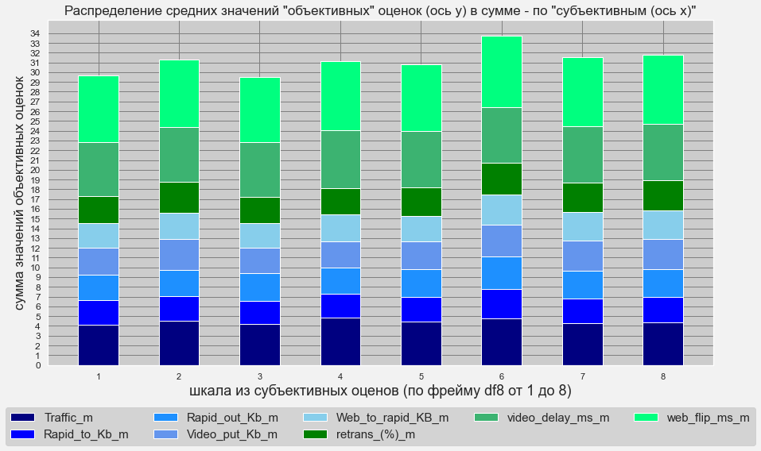

```python
c = list(range(1,9))   # размерность шкалы х
ww =[]                 # размерность шкаля у, настройка
for i in np.arange(0, 35.0, 1):
    ww.append(i)
plt.figure(figsize=[15, 8])
wd = 0.5
plt.bar(df_dir['Q1'], df_dir['Traffic_m'], color='Navy', width=wd, label='Traffic_m') #1

plt.bar(df_dir['Q1'], df_dir['Rapid_to_Kb_m'], color='Blue', width=wd, label='Rapid_to_Kb_m', #2
    bottom=df_dir['Traffic_m'])

plt.bar(df_dir['Q1'], df_dir['Rapid_out_Kb_m'], color='DodgerBlue', width=wd, label='Rapid_out_Kb_m', #3
    bottom=df_dir['Traffic_m']+df_dir['Rapid_to_Kb_m'])

plt.bar(df_dir['Q1'], df_dir['Video_put_Kb_m'], color='CornflowerBlue', width=wd, label='Video_put_Kb_m', #4
    bottom=df_dir['Traffic_m']+df_dir['Rapid_to_Kb_m']+df_dir['Rapid_out_Kb_m'])

plt.bar(df_dir['Q1'], df_dir['Web_to_rapid_KB_m'], color='SkyBlue', width=wd, label='Web_to_rapid_KB_m', #5
    bottom=df_dir['Traffic_m']+df_dir['Rapid_to_Kb_m']+df_dir['Rapid_out_Kb_m']+df_dir['Video_put_Kb_m'])


plt.bar(df_dir['Q1'], df_dir['retrans_(%)_m'], color='Green', width=wd, label='retrans_(%)_m', #6
    bottom=df_dir['Traffic_m']+df_dir['Rapid_to_Kb_m']+df_dir['Rapid_out_Kb_m']+df_dir['Video_put_Kb_m'] +
    df_dir['Web_to_rapid_KB_m'])


plt.bar(df_dir['Q1'], df_dir['video_delay_ms_m'], color='MediumSeaGreen', width=wd, label='video_delay_ms_m', #7
    bottom=df_dir['Traffic_m']+df_dir['Rapid_to_Kb_m']+df_dir['Rapid_out_Kb_m']+df_dir['Video_put_Kb_m'] +
    df_dir['Web_to_rapid_KB_m']+df_dir['Video_put_Kb_m'])



plt.bar(df_dir['Q1'], df_dir['web_flip_ms_m'], color='SpringGreen', width=wd, label='web_flip_ms_m', #8
    bottom=df_dir['Traffic_m']+df_dir['Rapid_to_Kb_m']+df_dir['Rapid_out_Kb_m']+df_dir['Video_put_Kb_m'] +
    df_dir['Web_to_rapid_KB_m']+df_dir['Video_put_Kb_m']+df_dir['video_delay_ms_m'])

plt.yticks(fontsize=12)

plt.title('Распределение средних значений "объективных" оценок (ось y) в сумме - по "субъективным (ось х)"', fontsize=17)
plt.xlabel('шкала из субъективных оценов (по фрейму df8 от 1 до 8)', fontsize=18)
plt.ylabel('сумма значений объективных оценок', fontsize=17)
plt.yticks(ww)
plt.xticks(c)
plt.legend(loc='lower center', ncol=5,  bbox_to_anchor=(0.5, -0.25),fontsize=15)
plt.show()
```

#### 8.3 Распределение технических проказателей, преобразованных в оценки

```python
# снять копию
dfqq = df8.copy()
```

```python
# добавть столбец суммареых объективных оценок всех характерисник
dfqq['sum'] = dfqq.loc[:,'Traffic_m':'web_flip_ms_m'].apply(np.sum, axis=1)
dfqq.head(1)
```

|  | user_id | Q1 | Q2 | Traffic_m | Rapid_to_Kb_m | Rapid_out_Kb_m | Video_put_Kb_m | Web_to_rapid_KB_m | retrans_(%)_m | video_delay_ms_m | web_flip_ms_m | sum |
| --- | --- | --- | --- | --- | --- | --- | --- | --- | --- | --- | --- | --- |
| 2 | 4 | 8 | 3 | 2 | 3 | 6 | 4 | 2 | 7 | 4 | 8 | 36 |

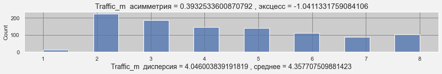

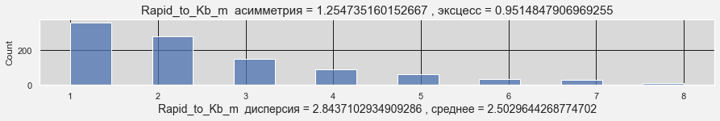

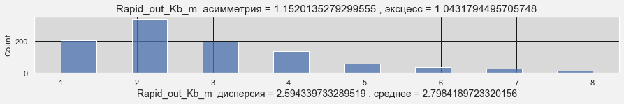

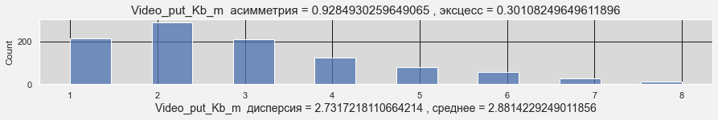

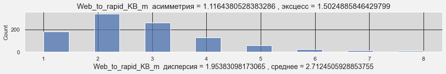

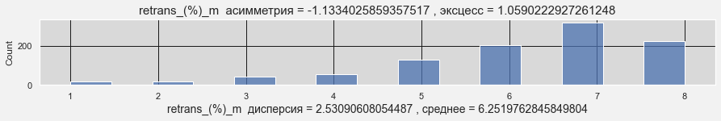

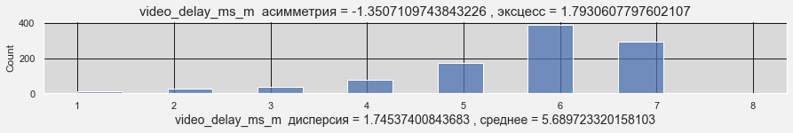

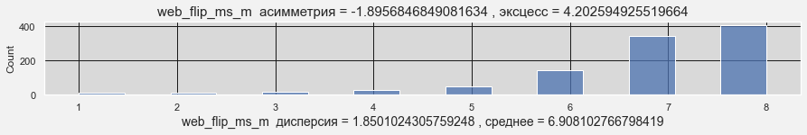

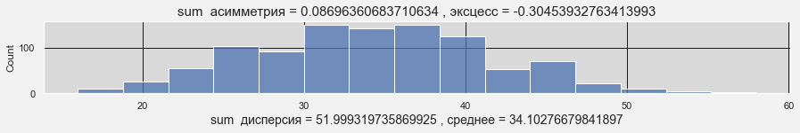

```python
numeric_features=[x for x in dfqq.columns if dfqq[x].dtype!="object"]
for i in dfqq[numeric_features[3:]].columns:
    plt.figure(figsize=(15,1.5))
    plt.title(i+'  '  +"асимметрия"+' = '+str(skew(dfqq[i]))      +' , '+ "эксцесс"+' = '+ str(kurtosis(dfqq[i])),fontsize=15  )
    plt.xlabel(i+'  ' +"дисперсия"+' = '+str((dfqq[i].std())**2) +' , '+ "среднее"+' = '+ str(dfqq[i].mean()) ,fontsize=14    )
    sns.histplot(dfqq[i], bins = 15)
    sns.set_style('darkgrid',
              {'axes.facecolor': '0.85',
               'grid.color': '0.1',
               'figure.facecolor': '0.95'})
plt.show()
```

#### 8.4 Распределение оценок в столбце Q1

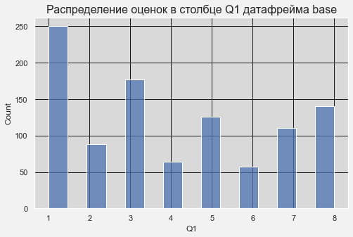

```python
plt.figure(figsize=(8,5))
sns.histplot(base.Q1, bins = 15)
plt.title("Распределение оценок в столбце Q1 датафрейма base",fontsize=16)
plt.show()
```

#### Распределение оценок в столбце Q1 - НЕ нормальное.

#### 8.5 Замечания по применяемому математическому аппарату

##### Корреляция между двумя переменными, каждая из которых имеет гауссово распределение, может быть рассчитана с использованием стандартных методов, таких как корреляция Пирсона. Эту процедуру нельзя использовать для данных, которые не имеют гауссовского распределения. Вместо этого должны использоваться методы ранговой корреляции

##### Ранговая корреляцияотносится к методам, которые определяют количество между переменными, используя порядковые отношения между значениями, а не конкретные значения. Порядковые данные - это данные, которые имеют значения меток и имеют отношение порядка или ранга; например: 'низкий‘,‘Средняя', а также 'высоко«.

##### Интуиция для теста состоит в том, что он вычисляет нормированную оценку для числа совпадающих или согласованных ранжирований между двумя выборками. Таким образом, этот тест также называется тестом соответствия Кендалла.

#### 8.6 Ранговая корреляция Кендалла. Корреляционная связь между оценками Q1 и оценками технических характеристик

##### 8.6.1 По сумме всех технических оценок

```python
xxx = list(dfqq['Q1']) # список РАНГОВЫХ случайных величин
yyy = list(dfqq['sum'])# список НОРМАЛЬНЫХ случайных величин
```

```python
coef_sum = kendalltau(xxx, yyy)
coef_sum
```

```
KendalltauResult(correlation=0.07541896056207811, pvalue=0.0009898379879597612)
```

##### 8.6.2 По массиву из минимальных у абонентов технических оценок, буде они поставили свои оценки "в сердцах" обидевшись на что-то их постоянно подводящее.

```python
dfqq['min'] = dfqq.loc[:,'Traffic_m':'web_flip_ms_m'].apply(np.min, axis=1)
dfqq.head(1)
```

|  | user_id | Q1 | Q2 | Traffic_m | Rapid_to_Kb_m | Rapid_out_Kb_m | Video_put_Kb_m | Web_to_rapid_KB_m | retrans_(%)_m | video_delay_ms_m | web_flip_ms_m | sum | min |
| --- | --- | --- | --- | --- | --- | --- | --- | --- | --- | --- | --- | --- | --- |
| 2 | 4 | 8 | 3 | 2 | 3 | 6 | 4 | 2 | 7 | 4 | 8 | 36 | 2 |

```python
xxxmi = list(dfqq['Q1'])
yyymi = list(dfqq['min'])
```

```python
coef_min = kendalltau(xxxmi, yyymi)
coef_min
```

```
KendalltauResult(correlation=0.07090064590088875, pvalue=0.007284601331490798)
```

##### Выводы по общему датафрейму df8 (base):

##### 1) по связи средней оценки всех технических характеристик и выставленной Q1 можно сказать, что а) по значению pvalue можем уверенно отвергнуть нулевую гипотезу о том, что выборки некоррелированы, b) коэффициент корреляции correlation=0.0754 свидетельствует об очень слабой корреляции.

##### 2) по связи минимальной оценки из всех технических характеристик и выставленной Q1 можно сказать, что а) по значению pvalue также можно уверенно отвергнуть нулевую гипотезу о том, что выборки некоррелированы, b) коэффициент корреляции correlation=0.0709 свидетельствует об очень слабой корреляции.

#### 8.7 Анализ наиболее популярных претензий

```python
# взять созданный
df8.head(1)
```

|  | user_id | Q1 | Q2 | Traffic_m | Rapid_to_Kb_m | Rapid_out_Kb_m | Video_put_Kb_m | Web_to_rapid_KB_m | retrans_(%)_m | video_delay_ms_m | web_flip_ms_m |
| --- | --- | --- | --- | --- | --- | --- | --- | --- | --- | --- | --- |
| 2 | 4 | 8 | 3 | 2 | 3 | 6 | 4 | 2 | 7 | 4 | 8 |

```python
# вычленить известные по Q2 самые популярные претензии
ujas = df8[(df8['Q2']==1)|(df8['Q2']==3)|(df8['Q2']==4)]
```

```python
len(ujas) # практически 90% от всего фрейма
```

```
916
```

```python
# список столбцов
oo = list(ujas.columns)[5:]
oo
```

```
['Rapid_out_Kb_m',
 'Video_put_Kb_m',
 'Web_to_rapid_KB_m',
 'retrans_(%)_m',
 'video_delay_ms_m',
 'web_flip_ms_m']
```

##### 8.7.1 == 1 недозв., обрывы

```python
ujas_1 = df8[(df8['Q2']==1)]
```

```python
sp1 = []
for i in oo:
    f1 = list(ujas_1.Q1)
    ff1 = list(ujas_1[i])
    ccoo = kendalltau(f1, ff1) # кортеж
    sp1.append(ccoo)
sp1
```

```
[KendalltauResult(correlation=0.06539237813578297, pvalue=0.06369923037552054),
 KendalltauResult(correlation=0.09968346039172603, pvalue=0.004578456201051753),
 KendalltauResult(correlation=0.07317263973069628, pvalue=0.040218192800871605),
 KendalltauResult(correlation=0.029775391291876188, pvalue=0.3999063652283231),
 KendalltauResult(correlation=0.0983854386250204, pvalue=0.0066223598544408735),
 KendalltauResult(correlation=0.03648128160667776, pvalue=0.3185393260252637)]
```

```python
pvalue = []
slo1 = {}
for i in range(len(sp1)):
    wm1 = sp1[i][1]
    wq1 = sp1[i][0]
    pvalue.append(wm1)
    if wm1 < 0.05:
        slo1[oo[i]] = wq1

slo1
```

```
{'Video_put_Kb_m': 0.09968346039172603,
 'Web_to_rapid_KB_m': 0.07317263973069628,
 'video_delay_ms_m': 0.0983854386250204}
```

```python
ujas_1df = pd.DataFrame(slo1,index=["coef"]).T # фрейм из словаря - с !!!!! обязательным !!!!! индексом
ujas_1df
```

|  | coef |
| --- | --- |
| Video_put_Kb_m | 0.099683 |
| Web_to_rapid_KB_m | 0.073173 |
| video_delay_ms_m | 0.098385 |

##### 8.7.2 == 3 плохое в зданиях

```python
ujas_3 = df8[(df8['Q2']==3)]
```

```python
sl3 = {}
sp3 = []
for i in oo:
    f3 = list(ujas_3.Q1)
    ff3 = list(ujas_3[i])
    ccoo = kendalltau(f3, ff3) # кортеж
    sp3.append(ccoo)
sp3
```

```
[KendalltauResult(correlation=0.06225464657655833, pvalue=0.18740962967352537),
 KendalltauResult(correlation=0.06979260494439136, pvalue=0.13348960501233254),
 KendalltauResult(correlation=0.09688937406407645, pvalue=0.039499362663579236),
 KendalltauResult(correlation=-0.0014520326515984048, pvalue=0.9751663820946439),
 KendalltauResult(correlation=0.03519851193154057, pvalue=0.460400817207699),
 KendalltauResult(correlation=0.10600736411310491, pvalue=0.02840475209386247)]
```

```python
pvalue = []
slo3 = {}
for i in range(len(sp3)):
    wm3 = sp3[i][1]
    wq3 = sp3[i][0]
    pvalue.append(wm3)
    if wm3 < 0.05:
        slo3[oo[i]] = wq3

slo3
```

```
{'Web_to_rapid_KB_m': 0.09688937406407645,
 'web_flip_ms_m': 0.10600736411310491}
```

```python
ujas_3df = pd.DataFrame(slo3,index=["coef"]).T  # фрейм из словаря - с !!!!! обязательным !!!!! индексом
ujas_3df
```

|  | coef |
| --- | --- |
| Web_to_rapid_KB_m | 0.096889 |
| web_flip_ms_m | 0.106007 |

##### 8.7.3.== '4 медлен. интернет'

```python
ujas_4 = df8[(df8['Q2']==4)]
```

```python
sl4 = {}
sp4 = []
for i in oo:
    f4 = list(ujas_4.Q1)
    ff4 = list(ujas_4[i])
    ccoo = kendalltau(f4, ff4) # кортеж
    sp4.append(ccoo)
sp4
```

```
[KendalltauResult(correlation=0.09068541813740796, pvalue=0.17392922655688192),
 KendalltauResult(correlation=0.09804984915449441, pvalue=0.13992165776843682),
 KendalltauResult(correlation=0.04753281788701225, pvalue=0.4792817268348206),
 KendalltauResult(correlation=0.12137233433323019, pvalue=0.06924570660441008),
 KendalltauResult(correlation=0.09282384422604317, pvalue=0.16603947504126504),
 KendalltauResult(correlation=0.08750259217125368, pvalue=0.1955000278082626)]
```

```python
pvalue = []
slo4 = {}
for i in range(len(sp4)):
    wm4 = sp4[i][1]
    wq4 = sp4[i][0]
    pvalue.append(wm4)
    if wm4 < 0.05:
        slo4[oo[i]] = wq4

slo4
```

```
{}
```

```python
ujuj = pd.concat([ujas_1df,ujas_3df])

ujuj = ujuj.sort_values(by='coef', ascending=False).reset_index()
ujuj
```

|  | index | coef |
| --- | --- | --- |
| 0 | web_flip_ms_m | 0.106007 |
| 1 | Video_put_Kb_m | 0.099683 |
| 2 | video_delay_ms_m | 0.098385 |
| 3 | Web_to_rapid_KB_m | 0.096889 |
| 4 | Web_to_rapid_KB_m | 0.073173 |

```python
# наиболее значимые корреляции
df_corr = ujuj.groupby('index').max().sort_values(by='coef', ascending=False)
df_corr
```

| index | coef |
| --- | --- |
| web_flip_ms_m | 0.106007 |
| Video_put_Kb_m | 0.099683 |
| video_delay_ms_m | 0.098385 |
| Web_to_rapid_KB_m | 0.096889 |

##### 8.7.4 Результаты по анализу корреляции среди популярных претензий

```python
ltlt = list(df_corr.index)
ltlt
```

```
['web_flip_ms_m', 'Video_put_Kb_m', 'video_delay_ms_m', 'Web_to_rapid_KB_m']
```

### 9. Сопоставление результатов, полученных методами бутстрепа и статистического теста

##### 9.1 О наличии ЗАВИСИМОСТИ между выставленными абонентами оценками и показателям технических характеричтик

##### График пункта 7.3.5

[figure not shown]

```python
c = list(range(1,10))
ww = list(range(1,8))
fig, ax = plt.subplots(figsize=(12,4))
plt.bar(df_p_value2.index, df_p_value2['the_trend_however'],width=0.75)
plt.title("Количество подтверждённых Ho-гипотез об отсутствии различий между средними массивов данных по группам оценок",fontsize=12)
plt.ylabel('количество отвергнутых нулевых гипотез',fontsize=9)
plt.xlabel('оценки абонентов',fontsize=10)
plt.yticks(ww)
plt.xticks(c)
plt.tick_params(labelsize=9) # ШРИФТ
```

##### и результат теста

```python
coef_sum
```

```
KendalltauResult(correlation=0.07541896056207811, pvalue=0.0009898379879597612)
```

##### одновременно говорят о НАЛИЧИИ такой зависимости, хотя и очень слабой, судя по коэффициенту корреляции.

##### 9.2 Совпадение технических характеристи, рекомендованных к модернизации по методу бутстрепа

```python
boot = df_p_value3s.sort_values(by='confirmed_null_hypotheses_in_technical').index[:4]
boo_l = list(boot)
boo_l
```

```
['video_delay_ms', 'Rapid_to_Kb', 'Web_to_rapid_Kb', 'web_flip_ms']
```

##### и технических характеристик, рекомендованных по результатам статистических тестов

```python
tes_l = list(df_corr.index)
tes_l
```

```
['web_flip_ms_m', 'Video_put_Kb_m', 'video_delay_ms_m', 'Web_to_rapid_KB_m']
```

#### или же по полным наименованиям: 1) Web Page Download Throughput(Kbps)-скорость загрузки web-страниц через браузер; 2) 'Video Streaming xKB Start Delay(ms)' - задержка старта воспроизведения видео 3)'Web Average TCP RTT(ms)' - пинг при просмотре web-страниц

### 10. Главный вывод

### Тем не менее, предпочтение, очевидно, остаётся за бутстрепом, как за методом, более точно описывающим взаимосвязи, работая не в одной конкретной выборке, а моделируя процессы в генеральной совокупности.